# Bayesian networks

Exercise done by Cédric Prieels for the Machine Learning II class. March 2020.

## Introduction

The daily occurrence of several meteorological parameters observed in the Parayas’ airport during 10 years approximately (sample size 3286) will be used for this task. In particular, the occurrence of lluvia (precipitation), nieve (snow), granizo (hail), tormenta (storm), niebla (fog), rocío (dew), escarcha (frost), nieve en el suelo (snow on the ground), neblina (haze) and viento (maximum wind gust above 50 km/h), all of them included in the text file meteoro.txt, will be considered. Note that all the variables have been discretized reflecting the occurrence/absence (binary) of the corresponding parameter.

Let's first of all download this meteoro.txt fil from Moodle, send it to the datasciencebhub and load it here in a data frame.

```r
setwd('/home/cprieels/Downloads/')
df <- read.table('meteoro.txt', header = TRUE, sep = "\t")
head(df) #Display the first lines just loaded
```

A data.frame: 6 × 10

|  | lluvia <fct> | nieve <fct> | granizo <fct> | tormenta <fct> | niebla <fct> | rocio <fct> | escarcha <fct> | nieveSuelo <fct> | neblina <fct> | viento <fct> |
| --- | --- | --- | --- | --- | --- | --- | --- | --- | --- | --- |
| 1 | s | n | n | n | n | n | n | n | n | s |
| 2 | s | n | n | n | n | n | n | n | n | s |
| 3 | s | n | n | s | n | n | n | n | n | s |
| 4 | s | n | n | n | n | n | n | n | n | s |
| 5 | s | n | s | s | n | n | n | n | n | s |
| 6 | s | n | s | s | n | n | n | n | n | s |

Now, install the packages we will need and load them.

```r
if(!require(bnlearn)) install.packages("bnlearn")
library(bnlearn)
```

```r
install.packages("BiocManager")
BiocManager::install()
BiocManager::install(c("graph", "Rgraphviz", "RBGL"))
```

```r
if(!require(gRain)) install.packages("gRain")
library(gRain)
library("Rgraphviz")
```

## Exercise 1

Taking into account the graph given in the instructions obtain the factorization of the joint probability distribution and write it in the same format used by the function modelstring included in the R-package bnlearn

```r
myModelstring <- "[viento][lluvia|viento][rocio|viento][niebla|viento:rocio][neblina|niebla][escarcha|rocio][tormenta|lluvia][granizo|tormenta][nieve|tormenta][nieveSuelo|nieve]"
```

Then, define the DAG in R using the model defined in the previous point.

```r
dag <- model2network(myModelstring)
print(dag)
```

```
  Random/Generated Bayesian network

  model:
   [viento][lluvia|viento][rocio|viento][escarcha|rocio][niebla|rocio:viento]
   [tormenta|lluvia][granizo|tormenta][neblina|niebla][nieve|tormenta]
   [nieveSuelo|nieve]
  nodes:                                 10
  arcs:                                  10
    undirected arcs:                     0
    directed arcs:                       10
  average markov blanket size:           2.00
  average neighbourhood size:            2.00
  average branching factor:              1.00

  generation algorithm:                  Empty
```

For each node, show the parents and childrens.

```r
for (node in nodes(dag)) {
    cat(paste("\n\nNow considering the node... ", node))
    cat(paste("\n   Parents: ", bnlearn::parents(dag, node)))
    cat(paste("\n   Children: ", bnlearn::children(dag, node)))
}
```

```
Now considering the node...  escarcha
   Parents:  rocio
   Children:

Now considering the node...  granizo
   Parents:  tormenta
   Children:

Now considering the node...  lluvia
   Parents:  viento
   Children:  tormenta

Now considering the node...  neblina
   Parents:  niebla
   Children:

Now considering the node...  niebla
   Parents:  rocio
   Parents:  viento
   Children:  neblina

Now considering the node...  nieve
   Parents:  tormenta
   Children:  nieveSuelo

Now considering the node...  nieveSuelo
   Parents:  nieve
   Children:

Now considering the node...  rocio
   Parents:  viento
   Children:  escarcha
   Children:  niebla

Now considering the node...  tormenta
   Parents:  lluvia
   Children:  granizo
   Children:  nieve

Now considering the node...  viento
   Parents:
   Children:  lluvia
   Children:  niebla
   Children:  rocio
```

**Built a list with the types of structures of the graph and clasify them as serial, diverging or converging structure.**

- Serial connection: both arcs have the same direction and follow one after the other;

Examples:

```
- viento - rocio - escarcha
- viento - rocio - niebla
- viento - niebla - neblina
- rocio - niebla - neblina

- viento - lluvia - tormenta
- lluvia - tormenta - nieve
- luvia - tormenta - granizo
- tormenta - nieve - nieveSuelo
```

- Divergent connection: the two arcs have divergent directions from a central node;

Examples:

```
- niebla - viento - rocio
- lluvia - viento - niebla
- nieve - tormenta - granizo
- niebla - rocio - escarcha
```

- Convergent connection: the two arcs converge to a central node. When there is no arc linking the two parents convergent connections are called v-structures.

Examples:

```
- viento - nieble - rocio (not an v-structure because of the direct arc between viento and rocio)
```

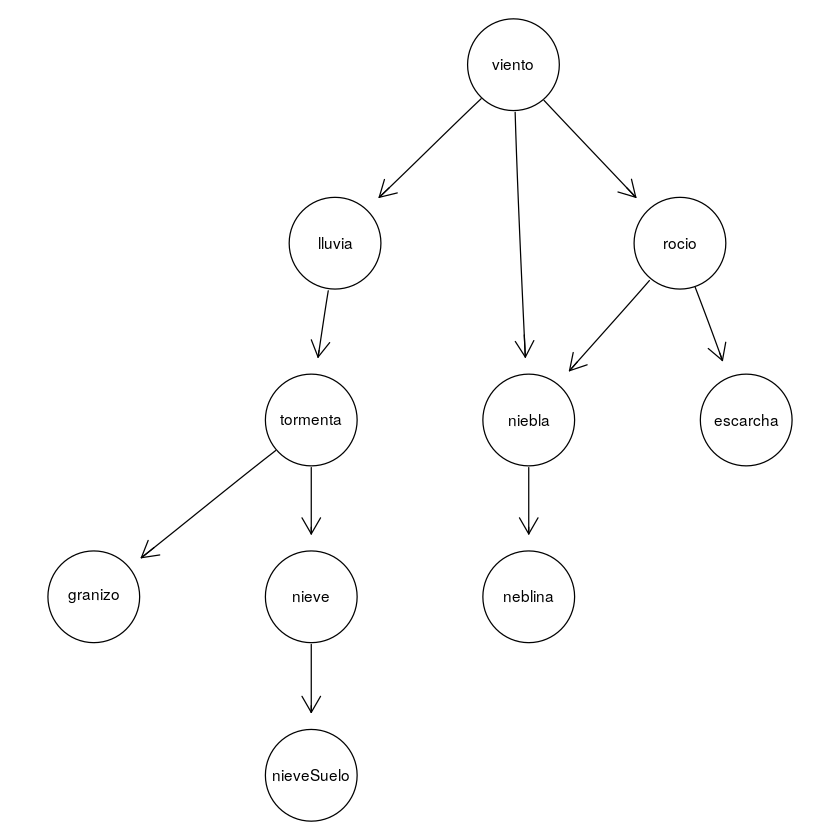

```r
graphviz.plot(dag)
```

Is there any v-structure in the graph? There is no v-structure in this graph. We can check that the only candidate (rocio, niebla, viento) is not a v-structure because of the direct link between viento and rocio.

```r
vstructs(dag)

dag2 <- drop.arc(dag, from="viento", to="rocio")
vstructs(dag2) #In this case we do have a v-structure, but not in the original dag
```

A matrix: 0 × 3 of type chr

| X | Z | Y |
| --- | --- | --- |

A matrix: 1 × 3 of type chr

| X | Z | Y |
| --- | --- | --- |
| rocio | niebla | viento |

Introduce a link from haze to frost and other from hail to precipitation. For each case, what happens? Have you obtained a well-defined Bayesian Network? If not, why?

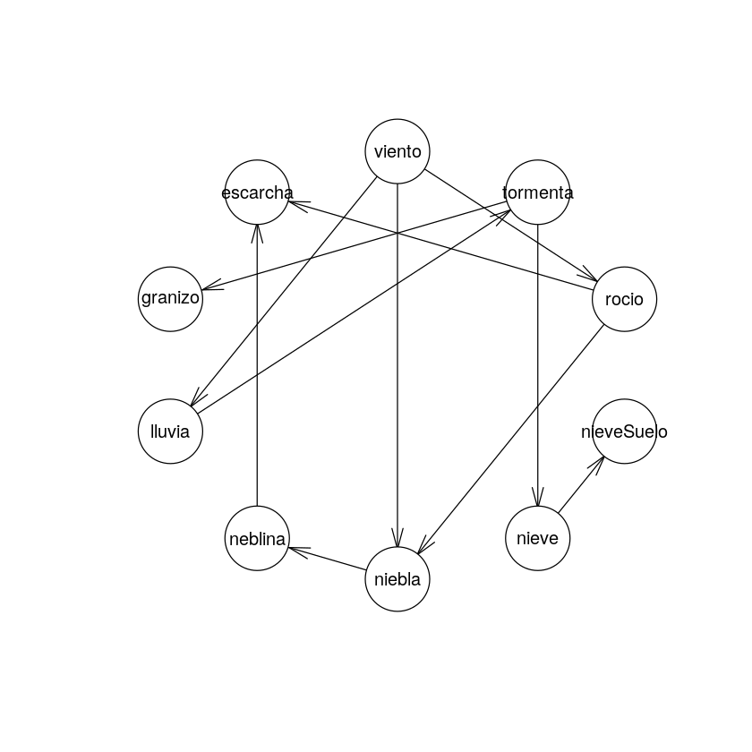

```r
newdag <- set.arc(dag, from="neblina", to="escarcha")
plot(newdag) #This works, no particular issue
```

```r
newdag <- set.arc(dag, from="granizo", to="lluvia")
plot(newdag) #This does not work to avoid the apparition of a cycle in the graph (with the tormenta node)
```

```
Error in arc.operations(x = x, from = from, to = to, op = "set", check.cycles = check.cycles, : the resulting graph contains cycles.
Traceback:

1. set.arc(dag, from = "granizo", to = "lluvia")
2. arc.operations(x = x, from = from, to = to, op = "set", check.cycles = check.cycles,
 .     check.illegal = check.illegal, debug = debug)
3. stop("the resulting graph contains cycles.")
```

Obtain the Markov Blanquet for the node dew.

```r
mb(dag, "rocio")
```

1. 'escarcha'

2. 'niebla'

3. 'viento'

**Introduce a link from precipitation to frog, Is there any change in the Markov Blanquet of dew? If yes, how does the Markov Blanquet change?**

It does appear to change, now the node lluvia enters in the markov blanquet of rocio and will have an impact on the conditional probability of this node.

```r
newdag <- set.arc(dag, from="lluvia", to="niebla")
mb(newdag, "rocio")
```

1. 'escarcha'

2. 'lluvia'

3. 'niebla'

4. 'viento'

## Exercise 2

Considering the data of the text file meteoro.txt and the previously defined DAG, build the Bayesian Network usint the Bayesian method of parametric learning.

```r
bn <- bn.fit(dag, data=df)
```

**Without using the factorization given by the DAG or the Bayesian Network learnt, what is the potential number of parameters of the joint probability function?**

If we don't use any of these factorization methods, we would expect to have 2^nodes - 1 (Yes/no, 10 nodes = 1023) parameters.

Given the Bayesian Network, how much parameters the joint probability function has?

```r
nparams(bn) #Number of parameters greatly reduced!
```

21

**Obtain the number of parameters for each of the local distribution corresponding to each node.**

model = [viento][lluvia|viento][rocio|viento][niebla|viento:rocio][neblina|niebla][escarcha|rocio][tormenta|lluvia][granizo|tormenta][nieve|tormenta][nieveSuelo|nieve]

- viento: 1 parameter = 1
- [lluvia|viento]: 1*2 parameters = 2
- [rocio|viento]: 1*2 parameters = 2
- [niebla|viento:rocio]: 1*2*2 parameters = 4
- [neblina|niebla]: 1*2 parameters = 2
- [escarcha|rocio]: 1*2 parameters = 2
- [tormenta|lluvia]: 1*2 parameters = 2
- [granizo|tormenta]: 1*2 parameters = 2
- [nieve|tormenta]: 1*2 parameters = 2
- [nieveSuelo|nieve]: 1*2 parameters = 2

Total = 1+2+2+4+2+2+2+2+2+2 = 21 parameters

Obtain and show in graphics the tables of conditional probability of the nodes hail and frog.

```
  Parameters of node granizo (multinomial distribution)

Conditional probability table:

       tormenta
granizo           n           s
      n 0.990262902 0.746341463
      s 0.009737098 0.253658537
```

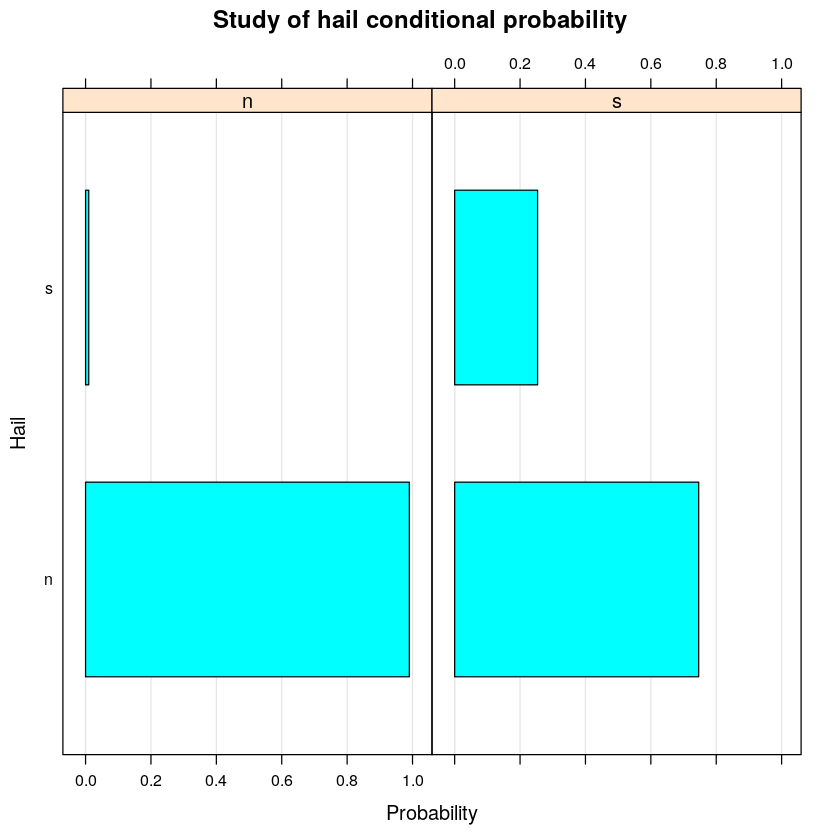

```r
bn$granizo
bn.fit.barchart(bn$granizo, main="Study of hail conditional probability", xlab="Probability", ylab="Hail")
```

```
  Parameters of node niebla (multinomial distribution)

Conditional probability table:

, , viento = n

      rocio
niebla           n           s
     n 0.946455131 0.855345912
     s 0.053544869 0.144654088

, , viento = s

      rocio
niebla           n           s
     n 0.995475113 0.937500000
     s 0.004524887 0.062500000
```

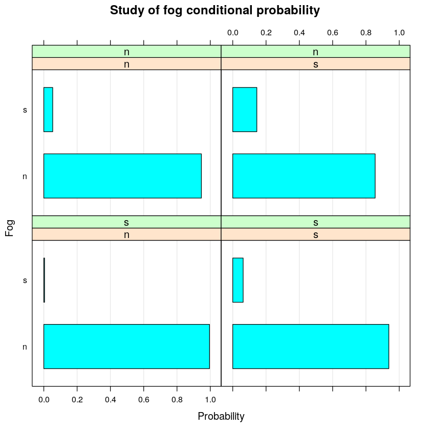

```r
bn$niebla
bn.fit.barchart(bn$niebla, main="Study of fog conditional probability", xlab="Probability", ylab="Fog")
```

## Exercise 3

Once the Bayesian Network has been built we can obtain the probability of any variable or subset of variables given any evidence. In other words, we can make inference based on the network.

Remember the concept of d-separación and take into account the DAG defined to reasonably and if the following questions are or not true:

- **Snow and hail are independent a priori.**

The path linking them is Nieve-Tormenta-Granizo, and there is no v-structures in the path. In this case, both are independant if any of the d-separation set (the observations given, here, an empty set) is in the separation path, so in this case, we cannot conclude that they are independant. FALSE.

- **Snow and hail are independent given the storm.**

The path linking them is Nieve-Tormenta-Granizo, and there is no v-structures in the path. In this case, both are independant if any of the d-separation set (here, Tormenta) is in the separation path, so in this case, we can conclude that snow and hail are independant given the storm. TRUE.

- **Snow on the ground and haze are independent.**

In this case, we have two paths to consider: path not passing through rocio and the one passing through rocio. Neither path has a v-structure so the justification and the answer is exactly the same as before: if the observation is in any path, they we can conclude they are independant. This is not the case here. FALSE.

- **Snow on the ground and haze are independent given the storm.**

In this case, we have two paths to consider: path not passing through rocio and the one passing through rocio. Neither path has a v-structure so the justification and the answer is exactly the same as before: if the observation is in any path, they we can conclude they are independant. This is the case here since tormenta is in both paths. TRUE.

Let's check these answers with some code.

```r
dsep(dag, x = "nieve", y = "granizo")
dsep(dag, x = "nieve", y = "granizo", z="tormenta")
dsep(dag, x = "nieveSuelo", y = "neblina")
dsep(dag, x = "nieveSuelo", y = "neblina", z="tormenta")
```

FALSE

TRUE

FALSE

TRUE

### Exact inference

Using the exact inference, obtain the probability of the following phenomenon knowing that storm has occurred:

- Precipitation occurs, P(lluvia=s|tormenta=s)
- There are wind gusts greater than 50 Km/h, P(viento=s|tormenta=s)
- Both of the previous, P(lluvia=s,viento=n|tormenta=s)
- Based on the previous results and knowing the storm has occurred a particular day:
  - Is the probability of rain/precipitation greater when storm occurs than any other day?
  - How does the storm affect to the probability of occurence of wind gusts greater than 50 km/h? It increases or decreses? How much?

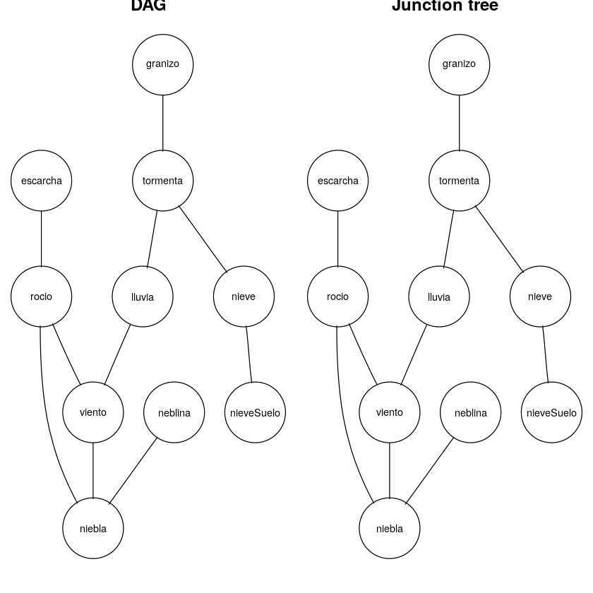

```r
junction <- compile(as.grain(bn))
par(mfrow=c(1,2))
plot(as.grain(bn))
title("DAG")
plot(compile(junction))
title("Junction tree")
```

Let's calculate the probability to have some rain if we know a storm has occured: 96.09%.

```r
jsex <- setEvidence(junction, nodes="tormenta", states="s") #We know a storm occured
querygrain(jsex, nodes = "lluvia")$lluvia
```

**n**

0.0390243902439024

**s**

0.960975609756098

Compute the probability to have wind gusts greater than 50km/h: 21.69%.

```r
querygrain(jsex, nodes="viento")$viento
```

**n**

0.78301670674436

**s**

0.21698329325564

Probability to have both the previous phenomena: 21.52%.

```r
querygrain(jsex, nodes = c("lluvia", "viento"), type="joint")
```

A matrix: 2 × 2 of type dbl

|  | n | s |
| --- | --- | --- |
| n | 0.037287003 | 0.7457297 |
| s | 0.001737387 | 0.2152459 |

Is the probability of rain/precipitation greater when storm occurs than any other day? In any given day, the probability to see rain is equal to 55.56% while it raised to 96.09% if we know a storm happened.

```r
querygrain(junction, nodes="lluvia")$lluvia #Now, we use the junction tree without the evidence set
```

**n**

0.444309190505173

**s**

0.555690809494827

How does the storm affect to the probability of occurence of wind gusts greater than 50 km/h? It increases or decreses? How much? If there is a storm, the probability to see some wind is equal to 21.69% while it is equal to 14.42% if we know nothing about the eventual existence of a storm.

```r
querygrain(junction, nodes="viento")$viento
```

**n**

0.855751673767498

**s**

0.144248326232502

### Inexact inference

Repeat the previous point but using inexact inference. For each probability obtain 100 estimations/realizations and draw a boxplot reflecting the spread of the probability estimation. Include also the exact value obtained in the previous point.

Mean probability to have some rain if we know a storm has occured: 96.20% instead of 96.09% (exact inference) with n = 5000 (default value). Setting n = 100 gives a probability of exactly 1. The higher the value of Monte Carlo simulations n, the closer we get to the previous probability value in general.

```
   Min. 1st Qu.  Median    Mean 3rd Qu.    Max.
 0.9341  0.9558  0.9628  0.9620  0.9678  0.9837
```

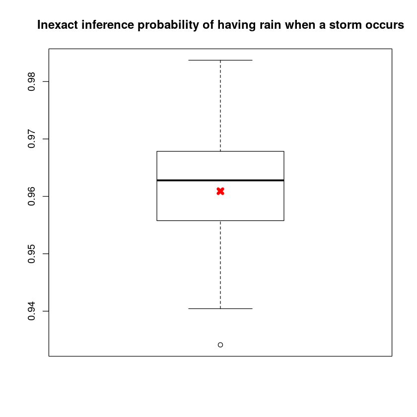

```r
probabilities <- c()
for (i in 1:100){
    probabilities[i] <- cpquery(bn, event = (lluvia == "s"), evidence = (tormenta == "s"))
}
summary(probabilities)
boxplot(probabilities, main="Inexact inference probability of having rain when a storm occurs")
points(0.9609, col="red", pch=4, lwd=5) #Exact inference value
```

Compute the mean probability to have wind gusts greater than 50km/h: 21.68% instead of 21.69% with n = 5000.

```
   Min. 1st Qu.  Median    Mean 3rd Qu.    Max.
 0.1677  0.2027  0.2149  0.2168  0.2317  0.2897
```

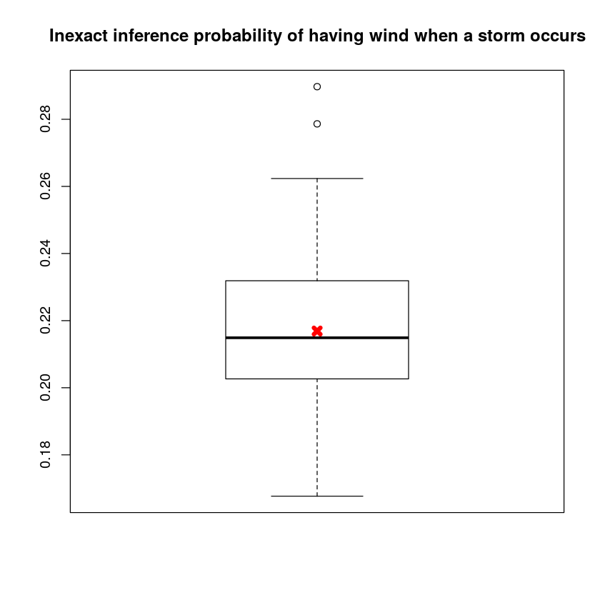

```r
probabilities <- c()
for (i in 1:100){
    probabilities[i] <- cpquery(bn, event = (viento == "s"), evidence = (tormenta == "s"))
}
summary(probabilities)
boxplot(probabilities, main="Inexact inference probability of having wind when a storm occurs")
points(0.2169, col="red", pch=4, lwd=5) #Exact inference value
```

Mean probability to have both the previous phenomena: 21.43% instead of 21.52%.

```
   Min. 1st Qu.  Median    Mean 3rd Qu.    Max.
 0.1580  0.2031  0.2129  0.2143  0.2297  0.2928
```

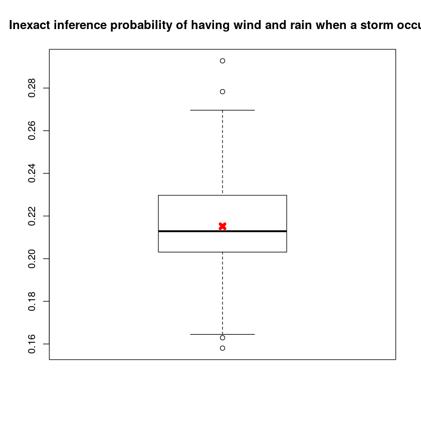

```r
probabilities <- c()
for (i in 1:100){
    probabilities[i] <- cpquery(bn, event = (viento == "s") & (lluvia == "s"), evidence = (tormenta == "s"))
}
summary(probabilities)
boxplot(probabilities, main="Inexact inference probability of having wind and rain when a storm occurs")
points(0.2152, col="red", pch=4, lwd=5) #Exact inference value
```

Is the probability of rain/precipitation greater when storm occurs than any other day? In any given day, the probability to see rain is equal to 55.67% (previously, 55.56%) while it raises to 96.20% (previously, 96.09%) if we know a storm happened.

```
   Min. 1st Qu.  Median    Mean 3rd Qu.    Max.
 0.5388  0.5515  0.5568  0.5567  0.5618  0.5740
```

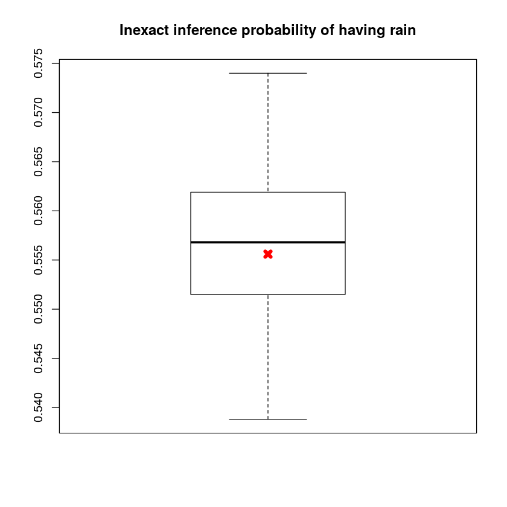

```r
probabilities <- c()
for (i in 1:100){
    probabilities[i] <- cpquery(bn, event = (lluvia == "s"), evidence = TRUE)
}
summary(probabilities)
boxplot(probabilities, main="Inexact inference probability of having rain")
points(0.5556, col="red", pch=4, lwd=5) #Exact inference value
```

How does the storm affect to the probability of occurence of wind gusts greater than 50 km/h? It increases or decreses? How much? If there is a storm, the mean probability to see some wind is equal to 21.68% (previously, 21.69%) while it is equal to 14.40% (previously, 14.42%) if we know nothing about the eventual existence of a storm.

```
   Min. 1st Qu.  Median    Mean 3rd Qu.    Max.
 0.1324  0.1404  0.1442  0.1440  0.1474  0.1620
```

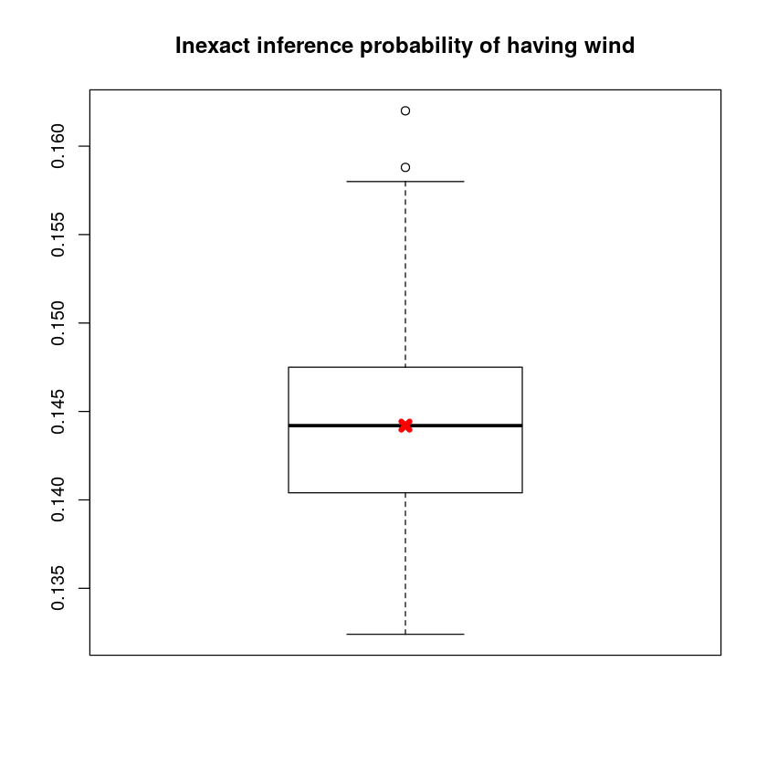

```r
probabilities <- c()
for (i in 1:100){
    probabilities[i] <- cpquery(bn, event = (viento == "s"), evidence = TRUE)
}
summary(probabilities)
boxplot(probabilities, main="Inexact inference probability of having wind")
points(0.1442, col="red", pch=4, lwd=5) #Exact inference value
```

## Exercise 4

As has be seen it is possible to learn the DAG from the data considering the proper algorithms. In particular, during the lessons the score-based hill-climbing algorithm, among others, has been explained and used. In addition both the expert and automatic approaches can be combined by introducing some constrains during the learning process. In order to obtain the strength of the dependence between nodes or to compare the performance of the model several scores have been also introduced.

**Obtain the statistical significance of the links defined by the meteorologist using the χ2 parameter. Is there any non-significant link? Which are the three strongest links and the nodes involved?**

```r
arc.strength(dag, data = df, criterion="x2")
```

A bn.strength: 10 × 3

|  | from <chr> | to <chr> | strength <dbl> |
| --- | --- | --- | --- |
| 1 | viento | lluvia | 5.887107e-48 |
| 2 | viento | rocio | 1.730098e-23 |
| 3 | viento | niebla | 1.591451e-05 |
| 4 | rocio | niebla | 2.087399e-17 |
| 5 | niebla | neblina | 1.300969e-27 |
| 6 | rocio | escarcha | 2.106559e-05 |
| 7 | lluvia | tormenta | 1.707081e-33 |
| 8 | tormenta | granizo | 3.189229e-104 |
| 9 | tormenta | nieve | 1.051550e-13 |
| 10 | nieve | nieveSuelo | 2.515328e-101 |

In addition to the hill-climbing algorithm, there is another widely used score-based algorithm called Tabu search and included in bnlearn by means of the function tabu, being the input similar to the ones shown for hill-climbing.

- **Compare the global score (BIC) obtained with the expert DAG and the ones obtained automatically using the algorithms tabu and hill-climbing. Which of them obtains the better score?**

The BIC obtained is quite similar for both methods, even though the tabu search method seems to perform a bit better.

- **To compare the original DAG with the obtained using tabu y hill-climbing, draw them using the function graphviz.plot. Based on the graphs obtained, in your opinion which one better reflects the cause-effect relationship between variables?**

```r
hc <- hc(df, debug=F)
hcScore <- bnlearn::score(hc, data = df, type="bic")
print(paste("hcScore: ", hcScore))

tabu <- tabu(df, debug=F)
tabuScore <- bnlearn::score(tabu, data = df, type="bic")
print(paste("tabuScore: ", tabuScore))
```

```
[1] "hcScore:  -9366.74970604666"
[1] "tabuScore:  -9365.17454049124"
```

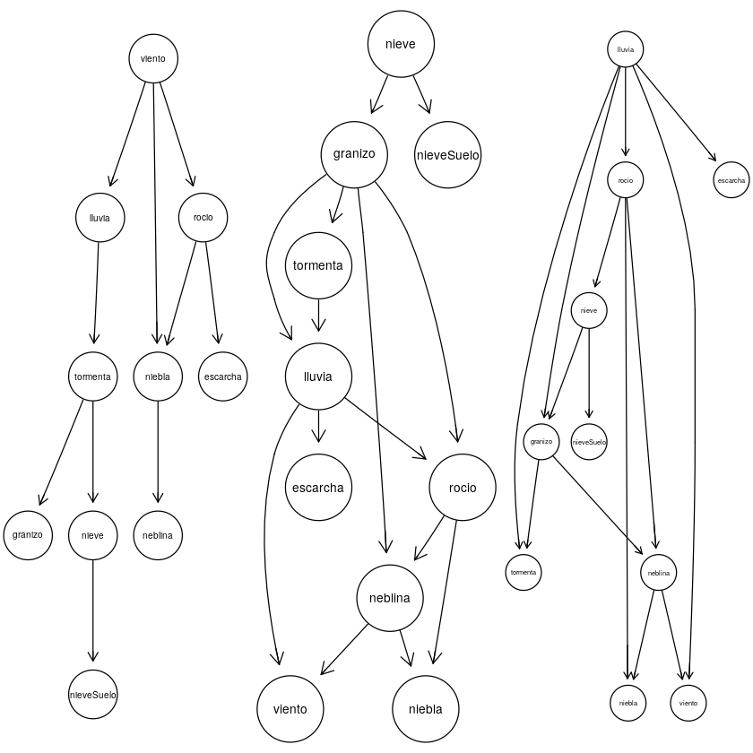

```r
#Let's now compare the DAG
par(mfrow=c(1,3))

#DAG original
hlight <- list(nodes = nodes(dag), arcs = arcs(dag), col="black", textCol = "black")
pp <- graphviz.plot(dag, highlight=hlight)

#hc DAG
hlight <- list(nodes = nodes(hc), arcs = arcs(hc), col="black", textCol = "black")
pp <- graphviz.plot(hc, highlight=hlight)

#tabu DAG
hlight <- list(nodes = nodes(tabu), arcs = arcs(tabu), col="black", textCol = "black")
pp <- graphviz.plot(tabu, highlight=hlight)
```

Learn again the DAG using tabu y hill-climbing, but including the following constrains/restrictions: 1. The links viento --> lluvia, tormenta --> granizo y nieve --> nieveSuelo must be included in the DAG. 2. It can not be a direct link between haze and hail, neither frog and storm.

```r
whitelist <- matrix(c("viento", "lluvia", "tormenta", "granizo", "nieve", "nieveSuelo"), ncol=2, byrow = TRUE, dimnames = list(NULL, c("from", "to")))
blacklist <- matrix(c("neblina", "granizo", "niebla", "tormenta"), ncol=2, byrow = TRUE, dimnames = list(NULL, c("from", "to")))
```

Draw the resulting DAGs and conclude which one is the better based on their BICs.

- **Calculate the strength of the links for the last two model combining expert knowledge and automatic learning.**
- **Comment briefly the obtained results.**

By adding the expert black and white lists, we can now see that both models give exactly the same links and therefore exactly the same arc strengths. The small differences between the models we previously observed have been removed thanks to the expert model we just added.

```
[1] "hcScore2:  -9361.87143450325"
```

A bn.strength: 14 × 3

|  | from <chr> | to <chr> | strength <dbl> |
| --- | --- | --- | --- |
| 1 | viento | lluvia | 5.887107e-48 |
| 2 | tormenta | granizo | 1.375034e-67 |
| 3 | nieve | nieveSuelo | 2.515328e-101 |
| 4 | lluvia | rocio | 1.588620e-78 |
| 5 | rocio | neblina | 9.575702e-44 |
| 6 | lluvia | tormenta | 9.350705e-27 |
| 7 | neblina | niebla | 8.140958e-19 |
| 8 | viento | neblina | 1.401866e-29 |
| 9 | lluvia | escarcha | 8.743909e-12 |
| 10 | viento | rocio | 1.009701e-08 |
| 11 | granizo | nieve | 1.243591e-28 |
| 12 | rocio | niebla | 4.868168e-09 |
| 13 | viento | granizo | 3.039235e-08 |
| 14 | viento | tormenta | 1.624833e-06 |

```
[1] "tabuScore2:  -9361.87143450325"
```

A bn.strength: 14 × 3

|  | from <chr> | to <chr> | strength <dbl> |
| --- | --- | --- | --- |
| 1 | viento | lluvia | 5.887107e-48 |
| 2 | tormenta | granizo | 1.375034e-67 |
| 3 | nieve | nieveSuelo | 2.515328e-101 |
| 4 | lluvia | rocio | 1.588620e-78 |
| 5 | rocio | neblina | 9.575702e-44 |
| 6 | lluvia | tormenta | 9.350705e-27 |
| 7 | neblina | niebla | 8.140958e-19 |
| 8 | viento | neblina | 1.401866e-29 |
| 9 | lluvia | escarcha | 8.743909e-12 |
| 10 | viento | rocio | 1.009701e-08 |
| 11 | granizo | nieve | 1.243591e-28 |
| 12 | rocio | niebla | 4.868168e-09 |
| 13 | viento | granizo | 3.039235e-08 |
| 14 | viento | tormenta | 1.624833e-06 |

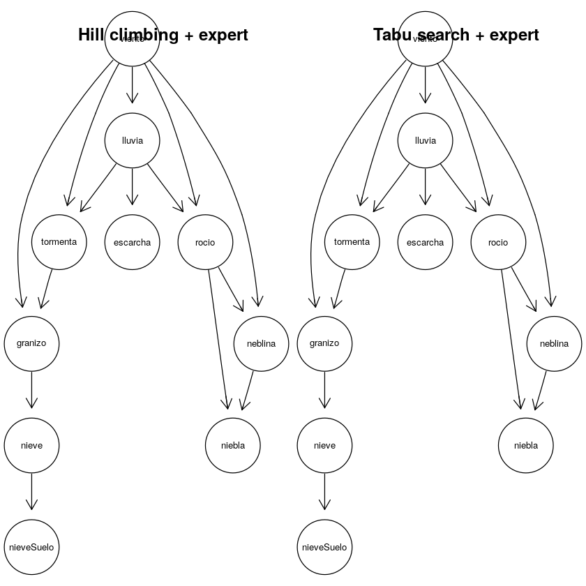

```r
#Hill climbing
hc2 <- hc(df, whitelist=whitelist, blacklist=blacklist)
hcScore2 <- bnlearn::score(hc2, data = df, type="bic")
print(paste("hcScore2: ", hcScore2))

strengthHc2 <- arc.strength(hc2, data = df, criterion = "x2")
strengthHc2

#Tabu
tabu2 <- tabu(df, whitelist=whitelist, blacklist=blacklist)
tabuScore2 <- bnlearn::score(tabu2, data = df, type="bic")
print(paste("tabuScore2: ", tabuScore2))

strengthTabu2 <- arc.strength(tabu2, data = df, criterion = "x2")
strengthTabu2

#Plot
par(mfrow=c(1,2))
graphviz.plot(hc2)
title("Hill climbing + expert")
graphviz.plot(tabu2)
title("Tabu search + expert")
```

```r
#Compare all the models
par(mfrow=c(1,1))
resultadosDAG <- matrix(c(hcScore, hcScore2, tabuScore, tabuScore2), ncol=2)
colnames(resultadosDAG) <- c("Score of the hill-climbing", "Score of the tabu search")
rownames(resultadosDAG) <- c("With restrictions","Without restrictions")
rtab <- as.table(resultadosDAG)
head(rtab)
```

[output not shown]